# DATA624 - Homework 5A

Esteban Aramayo

2022-06-28

# Week 5: Nonlinear Regression Models, Regression Trees and Rules-Based Models [27-Jun 3-Jul]

## Week 5A: Nonlinear Regression Models

The exercises are from the textbook “Applied Predictive Modeling” by KJ

### Exercise 7.2

`Friedman (1991)` introduced several benchmark data sets create by simulation.

One of these simulations used the following nonlinear equation to create data:

$y = 10 sin(\pi x_1 x_) + 20(x_3 − 0.5)^2 + 10x_4 + 5x_5 + N(0, \sigma^2)$

where the x values are random variables uniformly distributed between [0, 1] (there are also 5 other non-informative variables also created in the simulation).

The package `mlbench` contains a function called `mlbench.friedman1` that simulates these data:

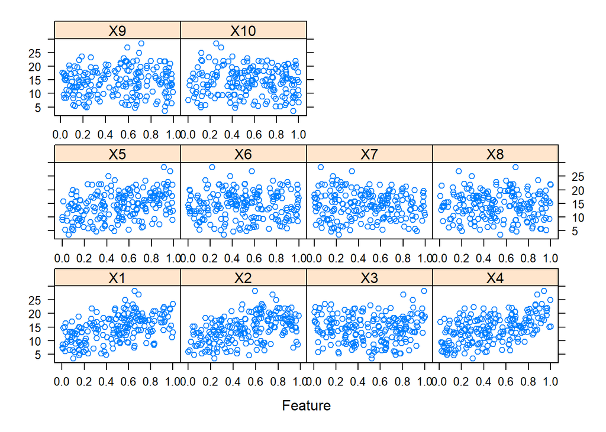

```r
library(caret)
library(mlbench)

set.seed(200)
trainingData <- mlbench.friedman1(200, sd = 1)
## We convert the 'x' data from a matrix to a data frame
## One reason is that this will give the columns names.
trainingData$x <- data.frame(trainingData$x)
## Look at the data using
caret::featurePlot(trainingData$x, trainingData$y)
```

```r
## or other methods.

## This creates a list with a vector 'y' and a matrix
## of predictors 'x'. Also simulate a large test set to
## estimate the true error rate with good precision:
testData <- mlbench.friedman1(5000, sd = 1)
testData$x <- data.frame(testData$x)
```

Tune several models on these data. For example:

```r
library(caret)
knnModel <- train(x = trainingData$x,
                  y = trainingData$y,
                  method = "knn",
                  preProc = c("center", "scale"),
                  tuneLength = 10)

knnModel
```

```
#> k-Nearest Neighbors
#>
#> 200 samples
#>  10 predictor
#>
#> Pre-processing: centered (10), scaled (10)
#> Resampling: Bootstrapped (25 reps)
#> Summary of sample sizes: 200, 200, 200, 200, 200, 200, ...
#> Resampling results across tuning parameters:
#>
#>   k   RMSE      Rsquared   MAE
#>    5  3.466085  0.5121775  2.816838
#>    7  3.349428  0.5452823  2.727410
#>    9  3.264276  0.5785990  2.660026
#>   11  3.214216  0.6024244  2.603767
#>   13  3.196510  0.6176570  2.591935
#>   15  3.184173  0.6305506  2.577482
#>   17  3.183130  0.6425367  2.567787
#>   19  3.198752  0.6483184  2.592683
#>   21  3.188993  0.6611428  2.588787
#>   23  3.200458  0.6638353  2.604529
#>
#> RMSE was used to select the optimal model using the smallest value.
#> The final value used for the model was k = 17.
```

```r
knnPred <- predict(knnModel, newdata = testData$x)
## The function 'postResample' can be used to get the test set
## perforamnce values
postResample(pred = knnPred, obs = testData$y)
```

```
#>      RMSE  Rsquared       MAE
#> 3.2040595 0.6819919 2.5683461
```

**Which models appear to give the best performance? Does MARS select the informative predictors (those named X1–X5)?**

#### Using a Neural Network model

First, we remove predictors to ensure that the maximum absolute pairwise correlation between the predictors is less than 0.75.

```r
tooHigh <- findCorrelation(cor(trainingData$x), cutoff = .75)

tooHigh
```

```
#> integer(0)
```

Since the correlation vector is empty, there are no predictors to remove. We can now fit a neural network model using the existing training set.

```r
# Resource: Chapter 7.5 of textbook "Applied Predictive Modeling" by KJ

## Create a specific candidate set of models to evaluate:
nnetGrid <- expand.grid(.decay = c(0, 0.01, .1),
                        .size = c(1:10),
                        .bag = FALSE)

# We can use caret to perform a grid search using 10-fold cross-validation.
# The train function generates a resampling estimate of performance. Because
# the training set size is not small, 10-fold cross-validation should produce
# reasonable estimates of model performance. The function trainControl specifies
# the type of resampling:
ctrl <- trainControl(method = "cv", number = 10)

nnetTune <- train(trainingData$x, trainingData$y,
                  method = "avNNet",
                  tuneGrid = nnetGrid,
                  trControl = ctrl,
                  ## Automatically standardize data prior to modeling
                  ## and prediction
                  preProc = c("center", "scale"),
                  linout = TRUE,
                  trace = FALSE,
                  MaxNWts = 10 * (ncol(trainingData$x) + 1) + 10 + 1,
                  maxit = 500)

nnetTune
```

```
#> Model Averaged Neural Network
#>
#> 200 samples
#>  10 predictor
#>
#> Pre-processing: centered (10), scaled (10)
#> Resampling: Cross-Validated (10 fold)
#> Summary of sample sizes: 180, 180, 180, 180, 180, 180, ...
#> Resampling results across tuning parameters:
#>
#>   decay  size  RMSE      Rsquared   MAE
#>   0.00    1    2.434845  0.7683498  1.921367
#>   0.00    2    2.497822  0.7558233  1.993325
#>   0.00    3    2.037885  0.8419795  1.609413
#>   0.00    4    1.900063  0.8584928  1.529545
#>   0.00    5    2.176661  0.8092998  1.628603
#>   0.00    6    2.743381  0.7255103  1.988222
#>   0.00    7    3.496229  0.6401273  2.493454
#>   0.00    8    4.034891  0.5941657  2.749735
#>   0.00    9    4.221796  0.5137164  2.800450
#>   0.00   10    4.682342  0.5848908  2.818883
#>   0.01    1    2.437231  0.7689665  1.934978
#>   0.01    2    2.510986  0.7596191  1.988260
#>   0.01    3    1.999944  0.8419567  1.555751
#>   0.01    4    2.003357  0.8445288  1.549723
#>   0.01    5    2.104801  0.8296459  1.664982
#>   0.01    6    2.314704  0.7997307  1.857949
#>   0.01    7    2.341101  0.8072335  1.872758
#>   0.01    8    2.205611  0.8163107  1.748153
#>   0.01    9    2.262921  0.8146166  1.776693
#>   0.01   10    2.453311  0.7709666  1.981977
#>   0.10    1    2.450897  0.7652309  1.942945
#>   0.10    2    2.489399  0.7606443  1.997060
#>   0.10    3    2.200693  0.8155496  1.786599
#>   0.10    4    2.059322  0.8432340  1.651716
#>   0.10    5    2.189025  0.8133603  1.729453
#>   0.10    6    2.215091  0.8128993  1.757966
#>   0.10    7    2.209521  0.8196474  1.786772
#>   0.10    8    2.317124  0.8010433  1.826655
#>   0.10    9    2.286711  0.7928430  1.849002
#>   0.10   10    2.238560  0.8113030  1.787851
#>
#> Tuning parameter 'bag' was held constant at a value of FALSE
#> RMSE was used to select the optimal model using the smallest value.
#> The final values used for the model were size = 4, decay = 0 and bag = FALSE.
```

Predict using the test data set and get the model’s performance values

```r
nnetPred <- predict(nnetTune, newdata = testData$x)
## The function 'postResample' can be used to get the test set
## performance values
postResample(pred = nnetPred, obs = testData$y)
```

```
#>     RMSE Rsquared      MAE
#> 2.496722 0.784618 1.685182
```

#### Using a Multivariate Adaptive Regression Splines (MARS) model

```r
# Resource: Chapter 7.5 of textbook "Applied Predictive Modeling" by KJ
# Resource: http://uc-r.github.io/mars

library(earth)
library(dplyr)

## Create a specific candidate set of models to evaluate:
marsGrid <- expand.grid(degree = 1:3,
                        nprune = seq(2, 100, length.out = 10) %>% floor()
  )

# We can use caret to perform a grid search using 10-fold cross-validation.
# The train function generates a resampling estimate of performance. Because
# the training set size is not small, 10-fold cross-validation should produce
# reasonable estimates of model performance. The function trainControl specifies
# the type of resampling:
ctrl <- trainControl(method = "cv", number = 10)


# cross validated model
tuned_mars <- train(
  x = trainingData$x,
  y = trainingData$y,
  method = "earth",
  metric = "RMSE",
  trControl = ctrl,
  tuneGrid = marsGrid
)

tuned_mars
```

```
#> Multivariate Adaptive Regression Spline
#>
#> 200 samples
#>  10 predictor
#>
#> No pre-processing
#> Resampling: Cross-Validated (10 fold)
#> Summary of sample sizes: 180, 180, 180, 180, 180, 180, ...
#> Resampling results across tuning parameters:
#>
#>   degree  nprune  RMSE      Rsquared   MAE
#>   1         2     4.334325  0.2599883  3.607719
#>   1        12     1.545349  0.8992979  1.243771
#>   1        23     1.529405  0.9018457  1.223874
#>   1        34     1.529405  0.9018457  1.223874
```

[output cut: 29 more lines]

Plot the MARS model results

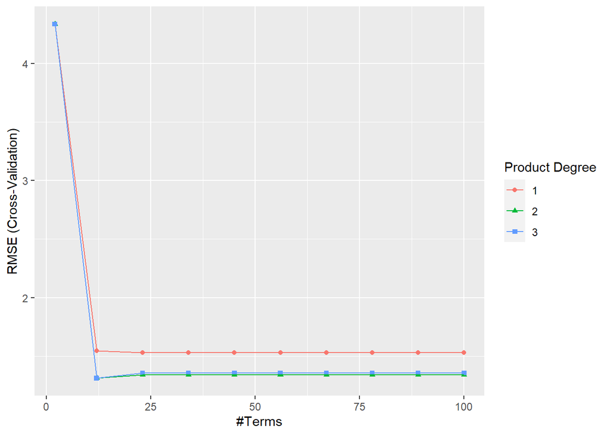

```r
ggplot(tuned_mars)
```

Show the best tuned MARS model

```r
# best chosen MARS model
tuned_mars$bestTune
```

```
#>    nprune degree
#> 12     12      2
```

Predict using the test data set and get the model’s performance values

```r
marsPred <- predict(tuned_mars, newdata = testData$x)
## The function 'postResample' can be used to get the test set
## performance values
postResample(pred = marsPred, obs = testData$y)
```

```
#>      RMSE  Rsquared       MAE
#> 1.2803060 0.9335241 1.0168673
```

#### Using a Support Vector Machines (SVM) model

```r
# Resource: Chapter 7.5 of textbook "Applied Predictive Modeling" by KJ

library(kernlab)


# We can use caret to perform a grid search using 10-fold cross-validation.
# The train function generates a resampling estimate of performance. Because
# the training set size is not small, 10-fold cross-validation should produce
# reasonable estimates of model performance. The function trainControl specifies
# the type of resampling:
ctrl <- trainControl(method = "cv", number = 10)


svmRTuned <- train(trainingData$x, trainingData$y,
                   method = "svmRadial",
                   preProc = c("center", "scale"),
                   tuneLength = 14,
                   trControl = ctrl)

svmRTuned
```

```
#> Support Vector Machines with Radial Basis Function Kernel
#>
#> 200 samples
#>  10 predictor
#>
#> Pre-processing: centered (10), scaled (10)
#> Resampling: Cross-Validated (10 fold)
#> Summary of sample sizes: 180, 180, 180, 180, 180, 180, ...
#> Resampling results across tuning parameters:
#>
#>   C        RMSE      Rsquared   MAE
#>      0.25  2.469506  0.7985704  1.979900
#>      0.50  2.217035  0.8125018  1.766726
#>      1.00  2.051120  0.8325247  1.618837
#>      2.00  1.965427  0.8450934  1.539666
#>      4.00  1.897161  0.8563701  1.500170
#>      8.00  1.862883  0.8615845  1.475808
#>     16.00  1.861693  0.8623909  1.474581
#>     32.00  1.861693  0.8623909  1.474581
#>     64.00  1.861693  0.8623909  1.474581
#>    128.00  1.861693  0.8623909  1.474581
#>    256.00  1.861693  0.8623909  1.474581
#>    512.00  1.861693  0.8623909  1.474581
#>   1024.00  1.861693  0.8623909  1.474581
#>   2048.00  1.861693  0.8623909  1.474581
#>
#> Tuning parameter 'sigma' was held constant at a value of 0.06192511
#> RMSE was used to select the optimal model using the smallest value.
#> The final values used for the model were sigma = 0.06192511 and C = 16.
```

Predict using the test data set and get the model’s performance values

```r
svmPred <- predict(svmRTuned, newdata = testData$x)
## The function 'postResample' can be used to get the test set
## performance values
postResample(pred = svmPred, obs = testData$y)
```

```
#>      RMSE  Rsquared       MAE
#> 2.0712382 0.8260501 1.5732943
```

**Which models appear to give the best performance? Does MARS select the informative predictors (those named X1–X5)?**

[output not shown]

### Exercise 7.5

Exercise 6.3 describes data for a chemical manufacturing process. Use the same data imputation, data splitting, and pre-processing steps as before and train several nonlinear regression models.

#### Solution

Load libraries used for Exercise 6.3

```r
library(RANN)
library(dplyr)
library(naniar)
library(caret)
```

#### Load the data

```r
library(AppliedPredictiveModeling)
data(ChemicalManufacturingProcess)
df_raw <- ChemicalManufacturingProcess
```

#### Perform imputation of missing values

```r
# check variables for missing values
# gg_miss_var(df_raw)
```

```r
preProcess_impute <- preProcess(df_raw, method ="knnImpute")
df <- predict(preProcess_impute, newdata = df_raw)
```

```r
# check variables for missing values
# gg_miss_var(df)
```

#### Remove near zero variance predictors

Predictors that have one unique value (i.e. are zero variance predictors) or predictors that are have both of the following characteristics: they have very few unique values relative to the number of samples and the ratio of the frequency of the most common value to the frequency of the second most common value is large.

```r
df <- df %>% select(!caret::nearZeroVar(.))
```

#### Splitting data in to training and test set

```r
# Create the training and test datasets
set.seed(100)
# Step 1: Get row numbers for the training data
trainRowNumbers <- createDataPartition(df$Yield, p=0.8, list=FALSE)
# Step 2: Create the training  dataset
trainData <- df[trainRowNumbers,]
# Step 3: Create the test dataset
testData <- df[-trainRowNumbers,]
```

#### Data preprocess applying centering and scaling

```r
preProcValues    <- preProcess(trainData, method = c("center", "scale"))
trainTransformed <- predict(preProcValues, trainData)
testTransformed  <- predict(preProcValues, testData)

xTrain <- trainTransformed %>% select(-Yield)
yTrain <- trainTransformed %>% select(Yield)

xTest  <- testTransformed %>% select(-Yield)
yTest  <- testTransformed %>% select(Yield)
```

#### Fit a KNN model

```r
knnChemModel <- train(x = xTrain,
                  y = yTrain$Yield,
                  method = "knn",
                  preProc = c("center", "scale"),
                  tuneLength = 10)

knnChemModel
```

```
#> k-Nearest Neighbors
#>
#> 144 samples
#>  56 predictor
#>
#> Pre-processing: centered (56), scaled (56)
#> Resampling: Bootstrapped (25 reps)
#> Summary of sample sizes: 144, 144, 144, 144, 144, 144, ...
#> Resampling results across tuning parameters:
#>
#>   k   RMSE       Rsquared   MAE
#>    5  0.7729445  0.4007219  0.6155921
#>    7  0.7815333  0.3869367  0.6257886
#>    9  0.7793118  0.3914364  0.6269750
#>   11  0.7788873  0.3934229  0.6297394
#>   13  0.7820317  0.3930332  0.6349738
#>   15  0.7867647  0.3851576  0.6386412
#>   17  0.7873253  0.3889346  0.6392012
#>   19  0.7909364  0.3831876  0.6429651
#>   21  0.7911040  0.3889180  0.6416521
#>   23  0.7925310  0.3925148  0.6427579
#>
#> RMSE was used to select the optimal model using the smallest value.
#> The final value used for the model was k = 5.
```

```r
knnChemPred <- predict(knnChemModel, newdata = xTest)
## The function 'postResample' can be used to get the test set
## perforamnce values
postResample(pred = knnChemPred, obs = yTest$Yield)
```

```
#>      RMSE  Rsquared       MAE
#> 0.6501442 0.4623051 0.5205731
```

#### Fit a Neural Network model

```r
tooHigh <- findCorrelation(cor(xTrain), cutoff = .75)

tooHigh
```

```
#>  [1]  2  4  6  7  1 11 43 30 29 41 40 20 26 24 21 53 37 36 56 42 51
```

Since the correlation vector is not empty, there are predictors to be removed. After removal, generate a new training and test sets of predictors.

```r
trainXnnet <- xTrain[, -tooHigh]
testXnnet  <- xTest[, -tooHigh]
```

We can now fit a neural network model using the existing training set.

```r
# Resource: Chapter 7.5 of textbook "Applied Predictive Modeling" by KJ

## Create a specific candidate set of models to evaluate:
nnetGrid <- expand.grid(.decay = c(0, 0.01, .1),
                        .size = c(1:10),
                        .bag = FALSE)

# We can use caret to perform a grid search using 10-fold cross-validation.
# The train function generates a resampling estimate of performance. Because
# the training set size is not small, 10-fold cross-validation should produce
# reasonable estimates of model performance. The function trainControl specifies
# the type of resampling:
ctrl <- trainControl(method = "cv", number = 10)

nnetChemTune <- train(xTrain, yTrain$Yield,
                  method = "avNNet",
                  tuneGrid = nnetGrid,
                  trControl = ctrl,
                  ## Automatically standardize data prior to modeling
                  ## and prediction
                  preProc = c("center", "scale"),
                  linout = TRUE,
                  trace = FALSE,
                  MaxNWts = 10 * (ncol(trainXnnet) + 1) + 10 + 1,
                  maxit = 500)

nnetChemTune
```

```
#> Model Averaged Neural Network
#>
#> 144 samples
#>  56 predictor
#>
#> Pre-processing: centered (56), scaled (56)
#> Resampling: Cross-Validated (10 fold)
#> Summary of sample sizes: 130, 129, 129, 129, 131, 129, ...
#> Resampling results across tuning parameters:
#>
#>   decay  size  RMSE       Rsquared   MAE
#>   0.00    1    0.7482484  0.5157903  0.5740126
#>   0.00    2    0.7670906  0.5273524  0.6228174
#>   0.00    3    0.7637153  0.4955543  0.6265964
#>   0.00    4    0.7452890  0.5685729  0.5967578
#>   0.00    5    0.8359766  0.4617132  0.6987576
#>   0.00    6    0.7416037  0.5544016  0.6147103
#>   0.00    7          NaN        NaN        NaN
#>   0.00    8          NaN        NaN        NaN
#>   0.00    9          NaN        NaN        NaN
#>   0.00   10          NaN        NaN        NaN
#>   0.01    1    0.7955973  0.5175823  0.6293428
#>   0.01    2    0.7960410  0.5555520  0.6448632
#>   0.01    3    0.7166066  0.6183926  0.5596929
#>   0.01    4    0.6805917  0.6109865  0.5386482
#>   0.01    5    0.6185713  0.6635756  0.4948506
#>   0.01    6    0.6797687  0.6151501  0.5380404
#>   0.01    7          NaN        NaN        NaN
#>   0.01    8          NaN        NaN        NaN
#>   0.01    9          NaN        NaN        NaN
#>   0.01   10          NaN        NaN        NaN
#>   0.10    1    0.7325230  0.5480941  0.5885330
#>   0.10    2    0.6751114  0.6177832  0.5525322
#>   0.10    3    0.6788970  0.6116242  0.5669672
#>   0.10    4    0.6410899  0.6367564  0.5099966
#>   0.10    5    0.6817571  0.6272634  0.5366705
#>   0.10    6    0.5983899  0.6787830  0.4756949
#>   0.10    7          NaN        NaN        NaN
#>   0.10    8          NaN        NaN        NaN
#>   0.10    9          NaN        NaN        NaN
#>   0.10   10          NaN        NaN        NaN
#>
#> Tuning parameter 'bag' was held constant at a value of FALSE
#> RMSE was used to select the optimal model using the smallest value.
#> The final values used for the model were size = 6, decay = 0.1 and bag = FALSE.
```

Predict using the test data set and get the model’s performance values

```r
nnetChemPred <- predict(nnetChemTune, newdata = xTest)
## The function 'postResample' can be used to get the test set
## performance values
postResample(pred = nnetChemPred, obs = yTest$Yield)
```

```
#>      RMSE  Rsquared       MAE
#> 0.5594510 0.6676931 0.4589402
```

#### Fit a MARS model

```r
# Resource: Chapter 7.5 of textbook "Applied Predictive Modeling" by KJ
# Resource: http://uc-r.github.io/mars

library(earth)
library(dplyr)

## Create a specific candidate set of models to evaluate:
marsGrid <- expand.grid(degree = 1:3,
                        nprune = seq(2, 100, length.out = 10) %>% floor()
  )

# We can use caret to perform a grid search using 10-fold cross-validation.
# The train function generates a resampling estimate of performance. Because
# the training set size is not small, 10-fold cross-validation should produce
# reasonable estimates of model performance. The function trainControl specifies
# the type of resampling:
ctrl <- trainControl(method = "cv", number = 10)


# cross validated model
tuned_ChemMARS <- train(
  x = xTrain,
  y = yTrain$Yield,
  method = "earth",
  metric = "RMSE",
  trControl = ctrl,
  tuneGrid = marsGrid
)

tuned_ChemMARS
```

```
#> Multivariate Adaptive Regression Spline
#>
#> 144 samples
#>  56 predictor
#>
#> No pre-processing
#> Resampling: Cross-Validated (10 fold)
#> Summary of sample sizes: 131, 129, 131, 130, 130, 128, ...
#> Resampling results across tuning parameters:
#>
#>   degree  nprune  RMSE       Rsquared   MAE
#>   1         2     0.7311847  0.4797663  0.5765448
#>   1        12     0.6268401  0.6363518  0.4961724
#>   1        23     0.6777858  0.5923480  0.5317603
#>   1        34     0.6777858  0.5923480  0.5317603
```

[output cut: 29 more lines]

Predict using the test data set and get the model’s performance values

```r
marsChemPred <- predict(tuned_ChemMARS, newdata = xTest)
## The function 'postResample' can be used to get the test set
## performance values
postResample(pred = marsChemPred, obs = yTest$Yield)
```

```
#>      RMSE  Rsquared       MAE
#> 0.5754156 0.6002260 0.4630585
```

#### Fit an SVM model

```r
# Resource: Chapter 7.5 of textbook "Applied Predictive Modeling" by KJ

library(kernlab)


# We can use caret to perform a grid search using 10-fold cross-validation.
# The train function generates a resampling estimate of performance. Because
# the training set size is not small, 10-fold cross-validation should produce
# reasonable estimates of model performance. The function trainControl specifies
# the type of resampling:
ctrl <- trainControl(method = "cv", number = 10)


svmChemRTuned <- train(xTrain, yTrain$Yield,
                   method = "svmRadial",
                   preProc = c("center", "scale"),
                   tuneLength = 14,
                   trControl = ctrl)

svmChemRTuned
```

```
#> Support Vector Machines with Radial Basis Function Kernel
#>
#> 144 samples
#>  56 predictor
#>
#> Pre-processing: centered (56), scaled (56)
#> Resampling: Cross-Validated (10 fold)
#> Summary of sample sizes: 130, 129, 129, 132, 129, 129, ...
#> Resampling results across tuning parameters:
#>
#>   C        RMSE       Rsquared   MAE
#>      0.25  0.7748155  0.4982164  0.6333898
#>      0.50  0.7066847  0.5452049  0.5836571
#>      1.00  0.6654443  0.5830103  0.5500636
#>      2.00  0.6434370  0.6058495  0.5263888
#>      4.00  0.6304889  0.6168851  0.5087674
#>      8.00  0.6226799  0.6238696  0.5038193
#>     16.00  0.6226799  0.6238696  0.5038193
#>     32.00  0.6226799  0.6238696  0.5038193
#>     64.00  0.6226799  0.6238696  0.5038193
#>    128.00  0.6226799  0.6238696  0.5038193
#>    256.00  0.6226799  0.6238696  0.5038193
#>    512.00  0.6226799  0.6238696  0.5038193
#>   1024.00  0.6226799  0.6238696  0.5038193
#>   2048.00  0.6226799  0.6238696  0.5038193
#>
#> Tuning parameter 'sigma' was held constant at a value of 0.01532961
#> RMSE was used to select the optimal model using the smallest value.
#> The final values used for the model were sigma = 0.01532961 and C = 8.
```

Predict using the test data set and get the model’s performance values

```r
svmChemPred <- predict(svmChemRTuned, newdata = xTest)
## The function 'postResample' can be used to get the test set
## performance values
postResample(pred = svmChemPred, obs = yTest$Yield)
```

```
#>      RMSE  Rsquared       MAE
#> 0.5648427 0.5929463 0.4521138
```

#### (a) Which nonlinear regression model gives the optimal resampling and test set performance?

Comparing all used models we can see that the **Neural Network (avNNet)** model yields the best performance in terms of the lowest RMSE = 0.5594510.

[output not shown]

#### (b) Which predictors are most important in the optimal nonlinear regression model? Do either the biological or process variables dominate the list? How do the top ten important predictors compare to the top ten predictors from the optimal linear model?

[output not shown]

```
  `1|ManufacturingProcess32 |4.0148629 | ManufacturingProcess32 |100.00000`
  2|ManufacturingProcess33 |2.5534232 | ManufacturingProcess13 |97.83640
  3|ManufacturingProcess28 |2.2725763 | BiologicalMaterial06   |82.21744
  4|ManufacturingProcess37 |2.1891986 | ManufacturingProcess17 |77.26777
  5|ManufacturingProcess13 |2.0341703 | BiologicalMaterial03   |76.21094
  6|ManufacturingProcess07 |1.7731421 | ManufacturingProcess36 |70.96498
  7|BiologicalMaterial05   |1.6380685 | BiologicalMaterial02   |68.78876
  8|ManufacturingProcess04 |1.6338725 | ManufacturingProcess09 |67.86384
  9|ManufacturingProcess16 |1.5879600 | BiologicalMaterial12   |63.36203
 10|BiologicalMaterial11   |1.5688048 | ManufacturingProcess06 |55.15443
```

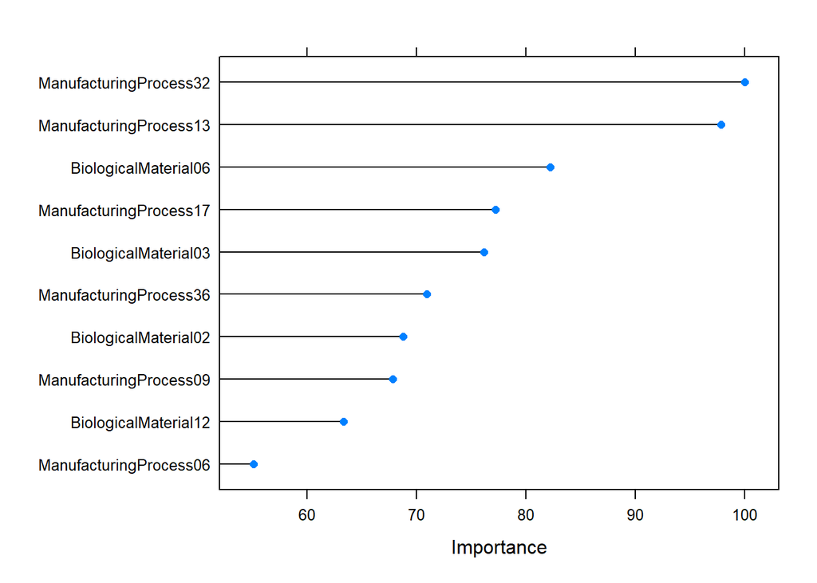

```r
plot(caret::varImp(nnetChemTune), top = 10)
```

```r
caret::varImp(nnetChemTune)
```

```
#> loess r-squared variable importance
#>
#>   only 20 most important variables shown (out of 56)
#>
#>                        Overall
#> ManufacturingProcess32  100.00
#> ManufacturingProcess13   97.84
#> BiologicalMaterial06     82.22
#> ManufacturingProcess17   77.27
#> BiologicalMaterial03     76.21
#> ManufacturingProcess36   70.96
#> BiologicalMaterial02     68.79
#> ManufacturingProcess09   67.86
#> BiologicalMaterial12     63.36
#> ManufacturingProcess06   55.15
#> BiologicalMaterial04     54.31
#> ManufacturingProcess33   49.35
#> ManufacturingProcess31   47.56
#> ManufacturingProcess11   45.87
#> BiologicalMaterial11     42.44
#> BiologicalMaterial08     41.89
#> ManufacturingProcess29   41.45
#> BiologicalMaterial01     41.19
#> BiologicalMaterial09     39.70
#> ManufacturingProcess02   37.13
```

#### (c) Explore the relationships between the top predictors and the response for the predictors that are unique to the optimal nonlinear regression model. Do these plots reveal intuition about the biological or process predictors and their relationship with yield?

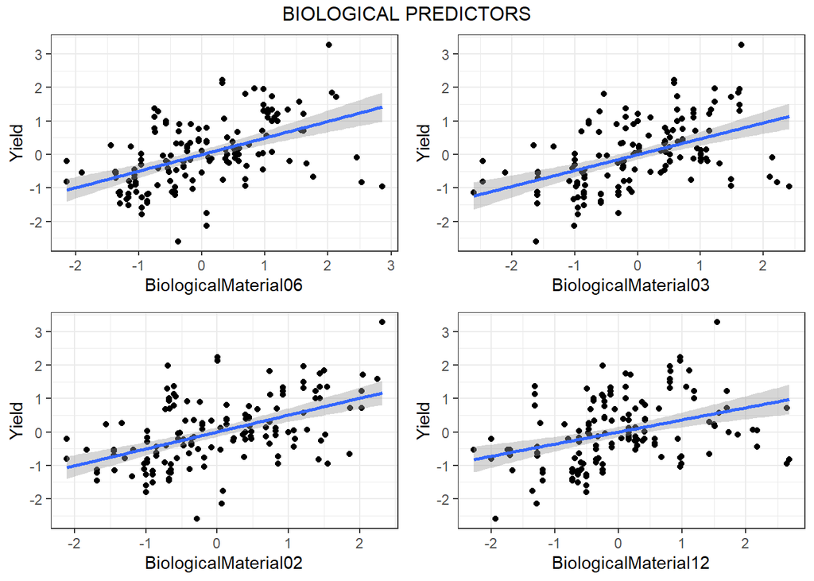

```r
library(gridExtra)

top9nnetPred <- trainTransformed %>%
   select(Yield,
          ManufacturingProcess13,
          BiologicalMaterial06,
          ManufacturingProcess17,
          BiologicalMaterial03,
          ManufacturingProcess36,
          BiologicalMaterial02,
          ManufacturingProcess09,
          BiologicalMaterial12,
          ManufacturingProcess06)

plt01 <- top9nnetPred %>%
  ggplot(aes(x = ManufacturingProcess13, y = Yield)) +
  geom_point() + geom_smooth(method = "lm") + theme_bw()

plt02 <- top9nnetPred %>%
  ggplot(aes(x = BiologicalMaterial06, y = Yield)) +
  geom_point()+ geom_smooth(method = "lm") + theme_bw()

plt03 <- top9nnetPred %>%
  ggplot(aes(x = ManufacturingProcess17, y = Yield)) +
  geom_point() + geom_smooth(method = "lm") + theme_bw()

plt04 <- top9nnetPred %>%
  ggplot(aes(x = BiologicalMaterial03, y = Yield)) +
  geom_point() + geom_smooth(method = "lm") + theme_bw()

plt05 <- top9nnetPred %>%
  ggplot(aes(x = ManufacturingProcess36, y = Yield)) +
  geom_point() + theme_bw()

plt06 <- top9nnetPred %>%
  ggplot(aes(x = BiologicalMaterial02, y = Yield)) +
  geom_point() + geom_smooth(method = "lm") + theme_bw()

plt07 <- top9nnetPred %>%
  ggplot(aes(x = ManufacturingProcess09, y = Yield)) +
  geom_point() + geom_smooth(method = "lm") + theme_bw()

plt08 <- top9nnetPred %>%
  ggplot(aes(x = BiologicalMaterial12, y = Yield)) +
  geom_point() + geom_smooth(method = "lm") + theme_bw()

plt09 <- top9nnetPred %>%
  ggplot(aes(x = ManufacturingProcess06, y = Yield)) +
  geom_point() + geom_smooth(method = "lm") + theme_bw()

# Biological Predictors
grid.arrange(plt02, plt04, plt06, plt08, nrow = 2, top = "BIOLOGICAL PREDICTORS")
```

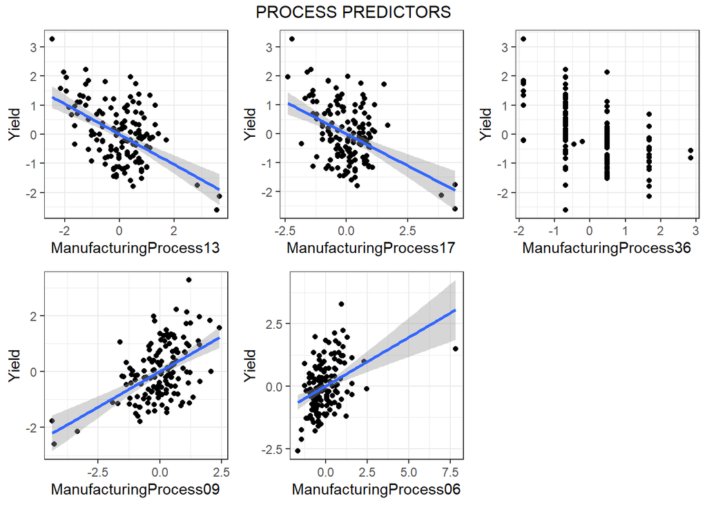

```r
# Process Predictors
grid.arrange(plt01, plt03, plt05, plt07, plt09,
             nrow = 2, top = "PROCESS PREDICTORS")
```

We use scatter plots between the top predictors and the response for the TOP 9 predictors that are unique to the optimal nonlinear regression model.